# Course Evaluation (15392-S18)

# General information

Seminar title: **National parliaments, international politics: enhanced democratic control?**  
Free University Berlin, MA-level, Summer 2018 [(15392-S18)](https://www.fu-berlin.de/vv/de/lv/431208?query=15392-S18&sm=383825)

Lecturer: [**Dr. Christian Rauh (WZB)**](http://www.christian-rauh.eu)  
Syllabus: [Online](https://www.dropbox.com/s/qbx7hlatxr33p5x/Syllabus_NatParlIntPol_Rauh_SS2018FU.pdf?dl=0)

Evaluation survey was conducted in the next to last week of the semester.  
Eight out of 12 regular participants responded (66.67%).  
The following graphs show the absolute count of responses if not otherwise indicated.

# Evaluation of individual teaching elements

## Interest and workload

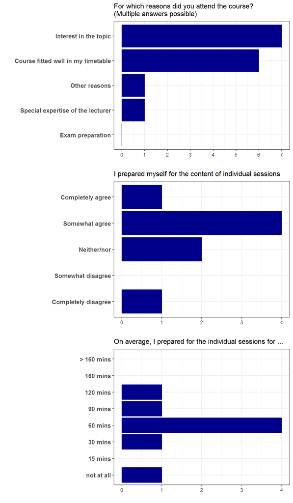

## Assessment of the requirements

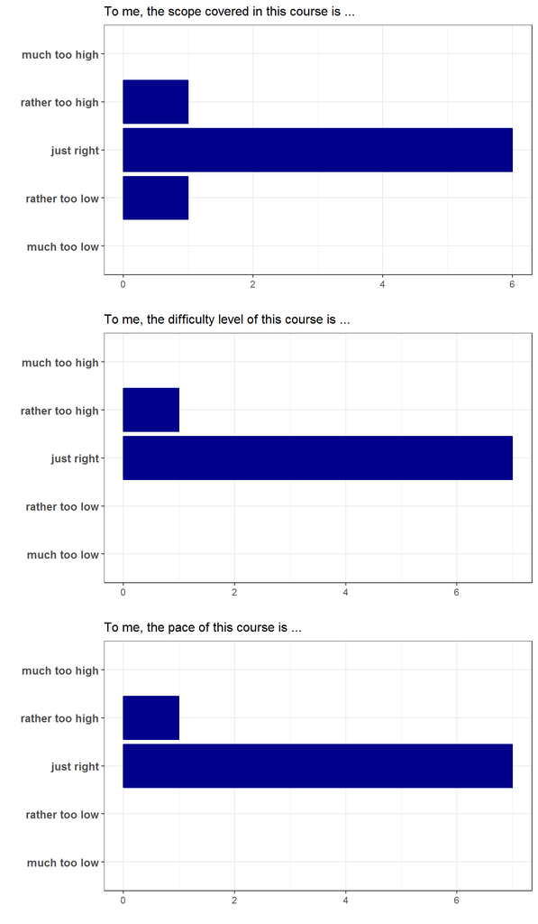

## Seminar structure

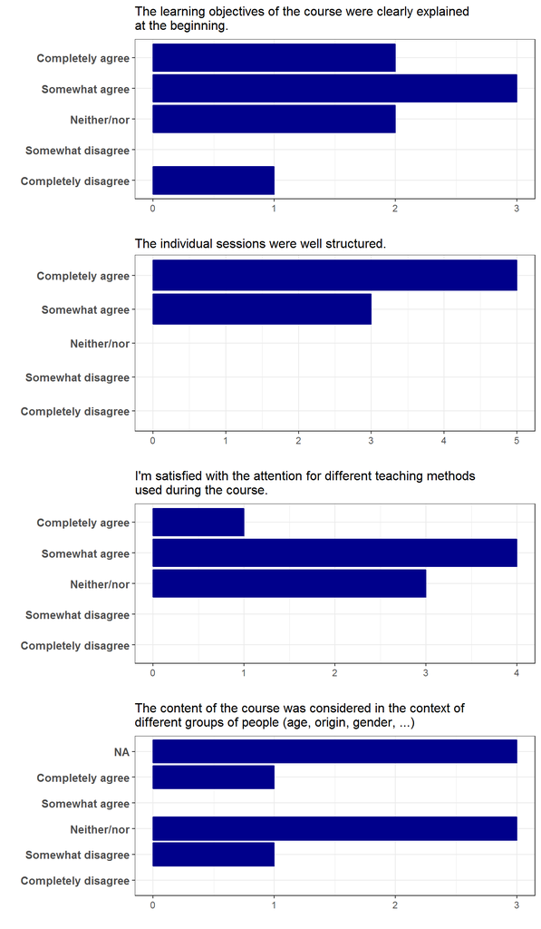

## Explanation, understanding, and discussion

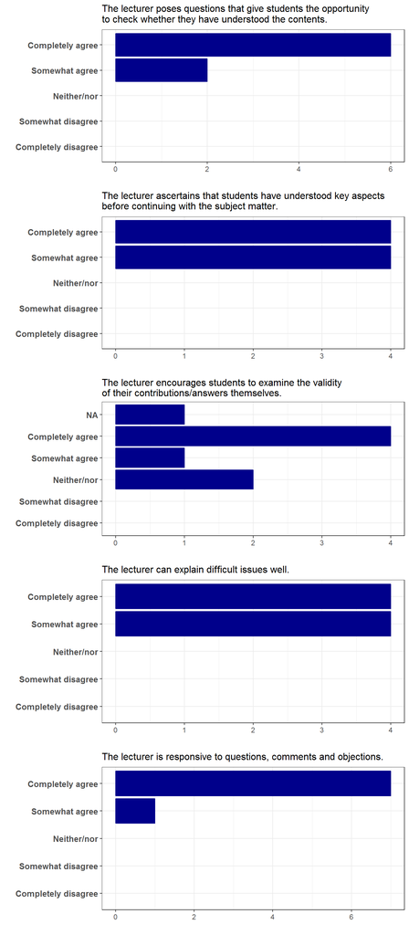

## Learning-oriented environment

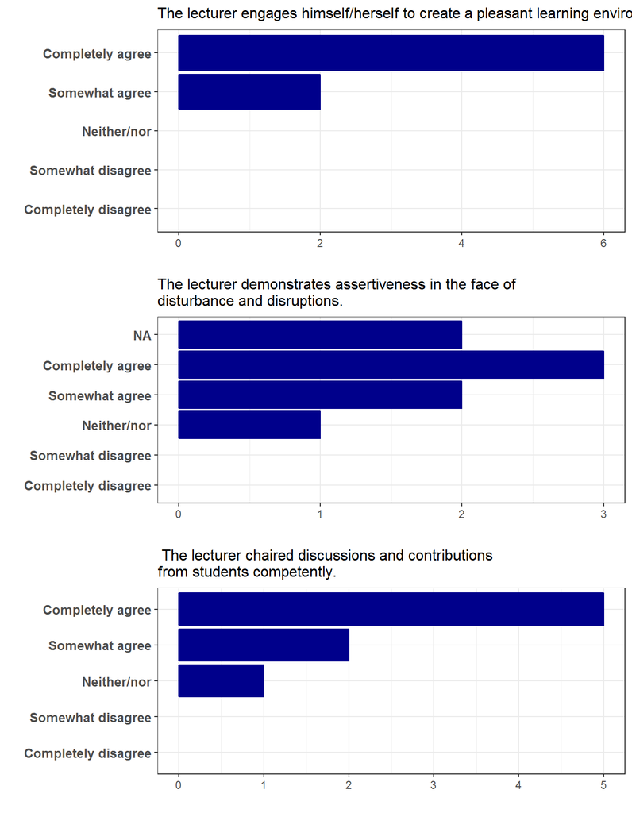

## Making use of time

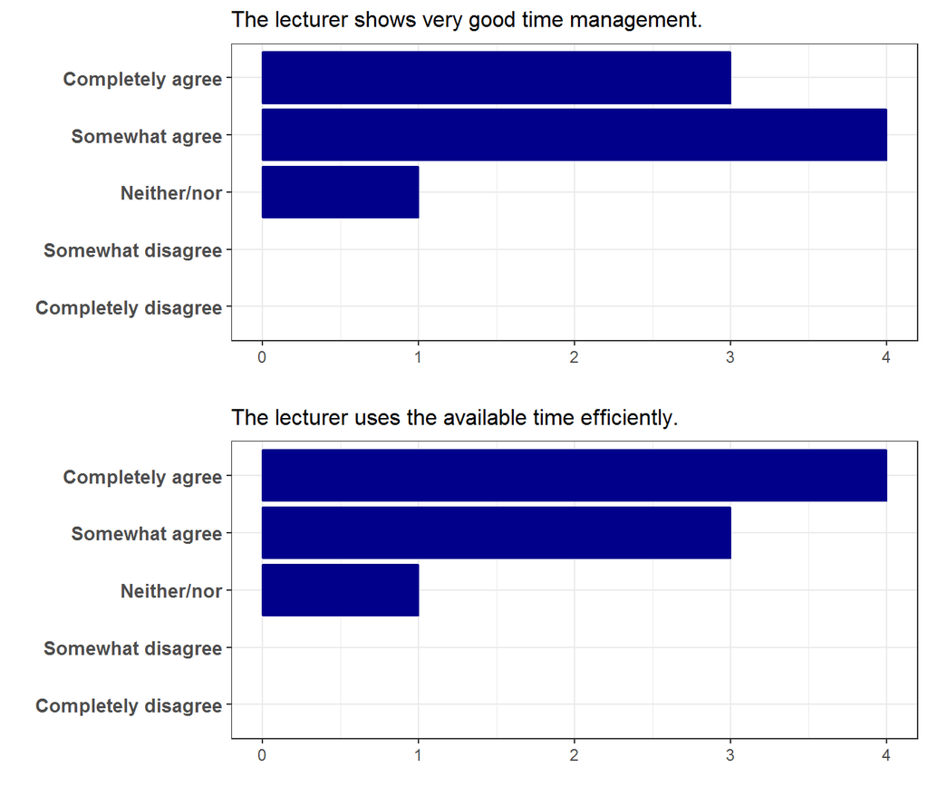

## Support and communication by the lecturer

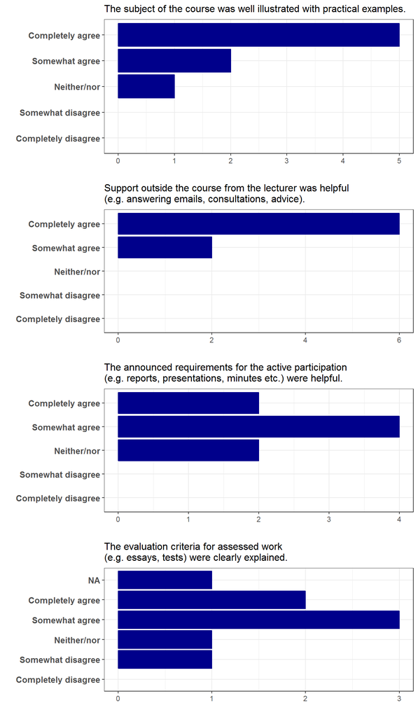

# Overall course evaluation

## General assessments

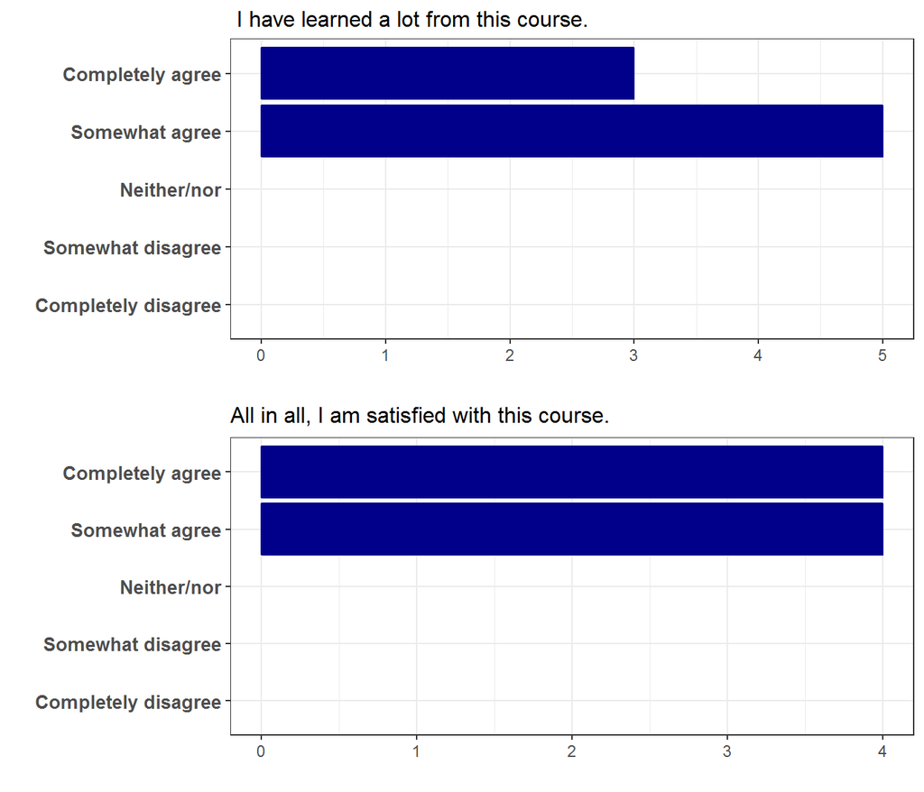

## Open feedback

### Things students particularly liked about the course

I liked the structure of the course as the lecturer gave insightful input on the basics of the topic at the beginning at the lesson and then there was room of discussion. I liked that the presentations of students didnt take too much time in the course, but were short and provided interesting additional information.

I found the presentation style of the lecturer very clear and engaging with no void intermissions.

I appreciate the selection of empirical studies.

The ability of the lecturer to react to participant’s comments and questions.

The delegation chain!

Familiar atmosphere Enough time for discussion Further information / data after sessions

Well structured course, very well versed lecturer regarding research and recent research results regarding the topic. Overall a nice learning atmosphere. I also enjoyed input from the lecturer since I had the feeling to take away new insights from class instead of only debating an issue at length without any learning effect.

- well structured
- one topic from different angles
- a lot of scientific papers
- helpful insights from lecturer
- power points help to understand the sessions and triggers further thinking

### Things students particularly disliked about the course

I guess, given the name of the course, it’s not appropriate to complain about this, but I would very much enjoy a session or two dedicated to the European Parliament. I remember the lecturer mentioning that this is a work in progress, therefore please understand this as an encouragement for such an effort.

Sometimes, the mandatory texts were rather demanding to read and took quite some time for preparation of the course. I assume this might have resulted in less preparation by participants in class.

- too many readings per session (not more than 2 papers per session) - as the papers are already quite complicated it takes a lot of time to fully understand them

### Suggestions for improvement

Perhaps the increased scope (for example European Parliament)

- plan in advance when students are presenting (not only your fault) - last session with 3 presentations was a bit overloaded